# EcoPuck file - calculation of spikes

Sari Giering (02 Oct 2020)

### File version history

2020 Apr 07: Colours for vertical plots are now generated using val2col  
2020 Apr 11: Remove 50 Hz interference  
2020 Apr 11: Use raw data (‘counts’) instead of *B532.4msr*, *B700.4msr* and *Chl.ugL* (Chunk: *Baseline-and-spikes*)  
2020 Apr 27: Reverse Apr 11 (use backscatter data) 2020 Apr 27: Delete text preamble 2020 Apr 27: Metadata now based on compiled data  
2020 Apr 27: New colour scheme for vertical plots  
2020 Oct 02: New bottom depth, SML and BNL depth (Filipa). Updated plots for publication.

# EcoPuck file processing 3: Calculation of spikes

Load EcoPuck data. All data have been cleaned, split, and converted to msr and Chl units according to factory calibration.

## Combine all data and produce meta table

```r
  library(antics)

  # Load files that have been matched with CTD profiles to get depth
  knitr::opts_knit$set(root.dir = "C:/Users/slcg/Dropbox/SOLSTICE/EK188")
  setwd("C:/Users/slcg/Dropbox/SOLSTICE/EK188")

  # load EcoTriplet data
  dat <- read.csv("EK188_EcoTriplet_all_casts.csv", header = T)

  # Get all file names
  file_list <- levels(as.factor(dat$Profile))

  # Remove empty file, and the too profiles that are too shallow (55 and 56)
  file_list <- file_list[!grepl("53|55|56",file_list)]

  # ignore unwanted profiles
  dat <- dat[!grepl("53|55|56", dat$Profile), ]

  # make empty data frame for meta data
  meta <- data.frame(Profile=character(),
                  Date=character(),
                  Time=character(),
                  Min_depth=numeric(),
                  Max_depth=numeric(),
                  Min_chl=numeric(),
                  Max_chl=numeric(),
                  stringsAsFactors=FALSE)

  # loop through files
  for (i in 1:length(file_list)) {

    # load profile
    eco         <- dat[dat$Profile == file_list[i],]

    # if empty file, next
    if (nrow(eco)==0) {
      print(paste("File is empty. File:", file_list[i], sep=" "))
      next
    }

    # make meta
    meta[i,"Profile"]   <- file_list[i]
    meta[i,"Date"]      <- as.character(eco$Date[1])
    meta[i,"Time"]      <- as.character(eco$Time[1])
    meta[i,"Min_depth"] <- min(eco$Depth)
    meta[i,"Max_depth"] <- max(eco$Depth)
    meta[i,"Min_chl"]   <- min(eco$Chl.ugL)
    meta[i,"Max_chl"]   <- max(eco$Chl.ugL)
  }
```

### Produce metadata table

Ok, now I extend the metadata using the cruise log.

```r
  knitr::opts_knit$set(root.dir = "C:/Users/slcg/Dropbox/SOLSTICE/EK188/")
  setwd("C:/Users/slcg/Dropbox/SOLSTICE/EK188/")

  log       <- read.csv("EK188_SOLSTICE_CruiseLog.csv", header=T)

  # Convert formats
  log$Date  <- strptime(log$Date..DDMMYYYY., format="%d%m%Y")
  log$Lat   <- as.numeric(as.character(substr(log$Latitude.start..DD.MM.MM.S.,1,2))) + as.numeric(as.character(substr(log$Latitude.start..DD.MM.MM.S.,4,8)))/60
  log$Lon   <- as.numeric(as.character(substr(log$Longitude.start..DD.MM.MM.E.,1,2))) + as.numeric(as.character(substr(log$Longitude.start..DD.MM.MM.E.,4,8)))/60

  log$Nbr   <- as.numeric(as.character(stringr::str_extract(log$ID,"[0-9]{3}")))

  # extract only CTDs
  ctd     <- log[log$Gear=="CTD",]
  ctd$ID  <- droplevels(as.factor(ctd$ID))

  # match with meta data
  meta$Nbr    <- as.numeric(as.character(stringr::str_extract(meta$Profile,"[0-9]{3}")))
  meta$Date   <- ctd$Date[match(meta$Nbr, ctd$Nbr)]
  meta$Lat    <- ctd$Lat[match(meta$Nbr, ctd$Nbr)]*-1
  meta$Lon    <- ctd$Lon[match(meta$Nbr, ctd$Nbr)]
  meta$Grid   <- ctd$Grid..[match(meta$Nbr, ctd$Nbr)]
  meta$CTD_ID <- ctd$ID[match(meta$Nbr, ctd$Nbr)]

  # delete missing row
  meta <- meta[!is.na(meta$Profile),]
```

### Depth horizons

Filipa calculated depth horizons using a variety of metrics to determine surface and bottom mixed layer. After discussions with her, Margaux and Alex, we decided on the MLD1_n2, BLD01 and BLD02.

| Column name | Definition |
| --- | --- |
| CAST | cast number |
| LAT | cast latitude |
| LON | cast longitude |
| dtime | cast time In format yyyy-mmm-dd HH:MM:SS |
| max_ctd_pres | maximum pressure recorded by the ctd cast |
| MLD125 | MLD defined by 0.125 density difference from surface density reference |
| MLD_n2 | max buoyancy frequency in the full cast |
| MLD1_n2 | max buoyancy frequency between surface and a depth where the density is 0.8 kg m^-3 higher than the surface (just to cap it and not finding bottom layer) |
| QI125 | Quality index for MLD 0.125 threshold (ideally want closer to 1 - anything below 0.5 is not defined, between 0.5 and 0.8 is defined with uncertainty, and over 0.8 is defined with certainty. The basis … |
| QI_n2 | Quality index for MLD defined by max(N^2) for the full cast |
| QI1_n2 | Quality index for MLD defined by max(N^2) |
| MLD_CHL | productive layer (= depth where we find 20% of the maximum chl in the profile - so always deeper than CHL max) |
| MLD_CHL_max | depth of the chlorophyll maximum in the profile |
| CHL_max | actual maximum chlorophyll concentration in the profile. Goes together with MLD_CHL_max |
| BLD01 | depth of the bottom layer defined by the 0.01 threshold |
| BLD02 | depth of the bottom layer defined by the 0.02 threshold |
| rmse_BLD01 | root mean square error (where rmse_BLD=sqrt(nanmean(full water column sigma)-nanmean(sigma(BLD to the bottom)).^2)); for the BLD01 definition |
| rmse_BLD02 | root mean square error (where rmse_BLD=sqrt(nanmean(full water column sigma)-nanmean(sigma(BLD to the bottom)).^2)); for the BLD02 definition |
| QI01_BLD | quality index - applied the same definition as the MLD QI. These are generally very close to 1. I’m using comparing to full water column sigma, instead of 1.5 MLD as previously defined by the paper |
| QI02_BLD | same for BLD02 definition |
| bottom_ref_dens | density used as reference density at the bottom; nanmedian(sigma) of the bottom 10m of the profile - used in BLD calculation |
| surf_ref_dens | density used as reference density at the surface; nanmedian(sigma) of the bottom 8m of the profile - used in the MLD threshold calculations (I usually use a shallower depth, but we often don’t have an… |
| Delta sigma | just difference of density between 2 depths |
| delta_sigma_surf_to_CHL_max | surface to the depth of the chlorophyll maximum |
| delta_sigma_surf_to_MLD125 | between surface and the MLD defined by the 0.125 threshold |
| delta_sigma_surf_to_40m | delta sigma in the upper 40 m |
| delta_sigma_surf_to_MLD1_n2 | this is MLD defined by max(N2) between the surface and a depth where density is 0.8 kg m-3 higher than the surface |
| delta_sigma_surf_to_MLD_n2 | this MLD is defined by max(N^2) in the whole profile |
| delta_sigma_BLD01_minus_5m | simple difference in sigma between the bottom layer depth (0.01 definition) and 5 m above that depth |
| max_n2_at_MLD_n2 | max of N^2 at the depth of MLD defined by max(N^2) |
| max_n2_at_MLD1_n2 | max of N^2 at the depth of MLD defined by max(N^2) between surface and the depth where density is 0.8 kg m-3 higher than the surface |

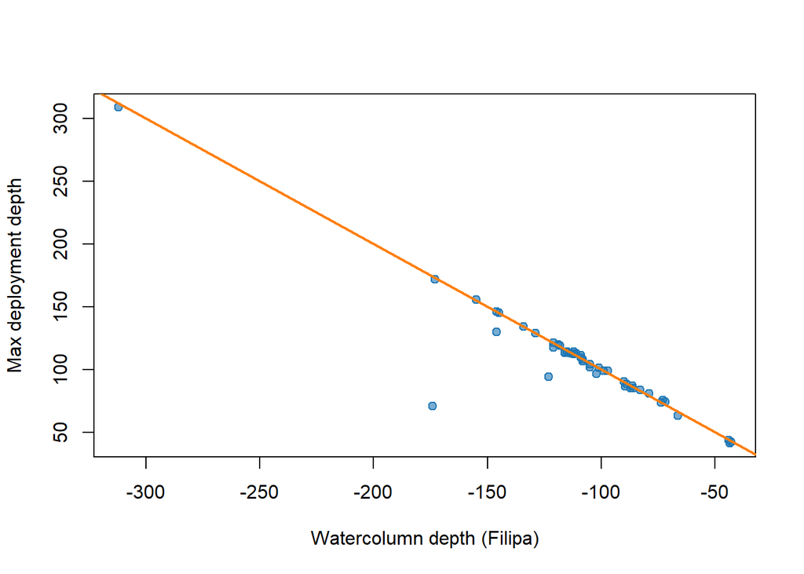

```r
  # new depths (SML, BML) from Filipa
  knitr::opts_knit$set(root.dir = "C:/Users/slcg/Dropbox/SOLSTICE/Data/")
  setwd("C:/Users/slcg/Dropbox/SOLSTICE/Data/")

  meta_depth        <- read.csv("2020-09-23 ctd_solstice_MLD.csv", header=T)

  # Add CTD identifier
  meta_depth$CTD_ID <- as.factor(paste("CTD", formatC(meta_depth$CAST, width = 3, format = "d", flag = "0"), sep=""))

  # Add depths
  meta$Bottom_depth   <- meta_depth$bottom_depth[match(meta$CTD_ID, meta_depth$CTD_ID)]
  meta$SML            <- meta_depth$MLD1_n2     [match(meta$CTD_ID, meta_depth$CTD_ID)]
  meta$BML01          <- meta_depth$BLD01       [match(meta$CTD_ID, meta_depth$CTD_ID)]
  meta$BML02          <- meta_depth$BLD02       [match(meta$CTD_ID, meta_depth$CTD_ID)]

  par(mfrow=c(1,1))
  plot(meta$Max_depth ~ c(meta$Bottom_depth*-1), ylab="Max deployment depth", xlab="Watercolumn depth (Filipa)", pch=21, col=d3[1], bg=add_alpha(d3[1],0.6))
  abline(0,-1, col=d3[2], lwd=2)
```

```r
  # Save meta file for future
  knitr::opts_knit$set(root.dir = "C:/Users/slcg/Dropbox/SOLSTICE/EK188/")
  setwd("C:/Users/slcg/Dropbox/SOLSTICE/EK188/")

  write.csv(meta, "EK188_metadata.csv", row.names=F)
```

### Maps

Now I plot the stations to get an idea about the spatial coverage. This seems to have some awesome code: https://stackoverflow.com/questions/54564050/r-how-to-set-the-extent-of-a-map-which-is-in-lambert-projection

```r
  # Load package
  library(marmap)
  library(cmocean)

  # Fetch data on NOAA servers and write on disk
  # x1, x2, y1, y2
  bat_full  <- getNOAA.bathy(20, 29, -37, -32, res = 2, keep=TRUE)
```

```
## File already exists ; loading 'marmap_coord_20;-37;29;-32_res_2.csv'
```

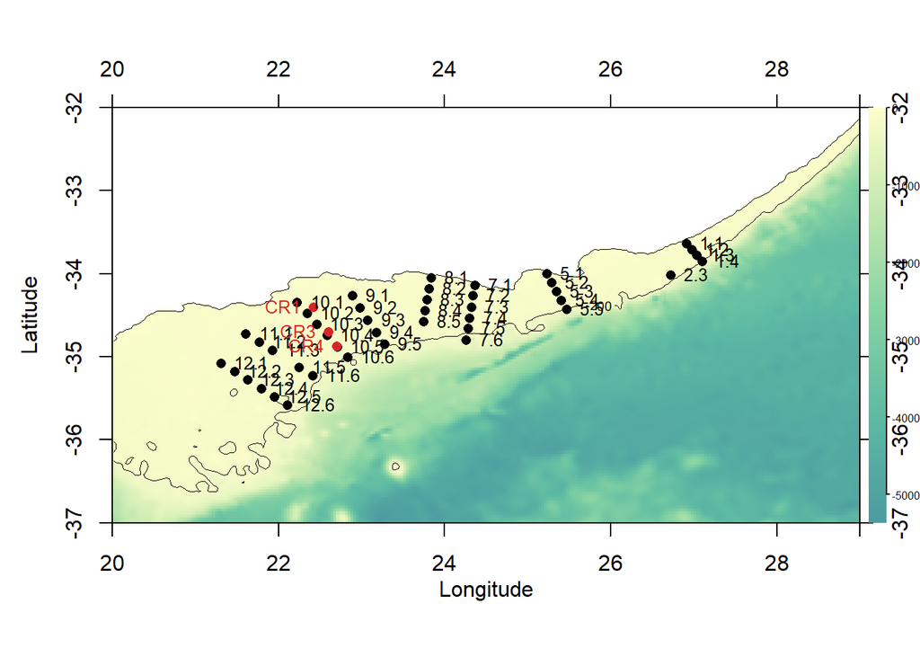

```r
  bat       <- bat_full

  # ------ Add colour scale --------------------------------------------------------
  # Colors can be constrained to bathymetry- and/or topography.
  # In this last case, a list of vectors is supplied to plot.bathy:
  # Each vector corresponds to a bathymetry/topography layer (for example, one layer for bathymetry and one layer for topography).
  # The first and second elements of the vector are the minimum and maximum bathymetry/topography, respectively.
  # The other elements of the vector (3, onward) correspond to colors.

  COL <- list(
    c(0, max(bat), "white"),
    c(min(bat), 0, rev(cmocean('deep')(10)[1:5]))
  )

  # ------ Plot bathymetry ---------------------------------------------------------
  par(bty='n')
  plot(bat, image = TRUE, land = TRUE, deep=0, shallow=0, step=0, lwd = 0.4, bpal=COL,
    xaxt='n', yaxt='n', xlim=c(20,29), ylab="", xlab="")

    axis(1, pos=-37, at=c(20,22,24,26,28,29), labels=c(20,22,24,26,28,NA))
    axis(2, pos=20)
    axis(3, pos=-32,at=c(20,22,24,26,28,29), labels=c(20,22,24,26,28,NA))
    axis(4, pos=29)

    mtext("Longitude", 1, line= 2)
    mtext("Latitude",  2, line= 2.5)

    # add 200 m isobath
    plot(bat, deep = -200, shallow = -200, step = 0, lwd = 0.5, add = TRUE, drawlabels = TRUE)

  # ------ Add colour bar on the side ------------------------------------
  vertical.image.legend(
    col = colorRampPalette(cmocean('deep')(10)[5:1])(100),
    zlim = as.numeric(COL[[2]][1:2]))

  # ------ Add stations ------------------------------------------------------------
  # remove duplicate station 9.1
  meta_sub <- meta[meta$CTD_ID != "CTD029",]

  # add colour for CR stations
  meta_sub$COL <- "black"
  meta_sub$COL [grepl("CR", meta_sub$Grid)] <- d3["red"]

  meta_sub$POS <- 4
  meta_sub$POS[grepl("CR", meta_sub$Grid)] <- 2

  points(
    x = meta_sub$Lon,
    y = meta_sub$Lat,
    pch = 16, cex = 1,
    col = meta_sub$COL)

  # Add the station numbers just to see that everything plotted correctly
  text(
    x = meta_sub$Lon,
    y = meta_sub$Lat,
    col = meta_sub$COL,
    label = meta_sub$Grid,
    offset = 0.5,
    pos = meta_sub$POS,
    cex=0.8)
```

# Backscatter spike analysis

The sensor signal is partitioned into three components:

`F = l + s + r + Ɛ`

where the full signal (F) is a composed of large (l), small (s), a blank value (r) and noise (Ɛ).

The blank value was calculated from deep profiles recorded during COMICS2, and they have been subtracted during the conversion (*EcoPuck_processing_2*). Hence:

`r = 0`

The noise was calculated as the standard deviation of the blank value (*EcoPuck_processing_2*) (see Table).

| _ | ECO Chlorophyll Fluorometer | Scattering meter at 700 nm | Scattering meter at 532 nm |
| --- | --- | --- | --- |
| Scale Factor - factory (SFf) | 0.0305 ug/L/count | 3.004E-06 (m-1sr-1)/counts | 6.974E-06 (m-1sr-1)/counts |
| Scale Factor - measured (SFm) | 0.0626 ug/L/count | N/A | N/A |
| Dark Counts (deep casts) | 47 ± 5 counts | 62 ± 6 counts | 27 ± 5 counts |
| Uncertainty | ± 0.313 ug/L | ± 1.8024e-05 m-1sr-1 | ± 3.487e-05 m-1sr-1 |

Small particles are here associated as the ‘baseline’ signal and are calculated using a running minimum. Baseline signal is calculated according to Briggs in a two 2-step process:

1. Running minimum 11-point (high frequency data hence higher running mean value)
2. Running maximum 11-point

This process assumes that there are frequent periods when no large particles are present. This assumption does not work for our cruise, so I therefore only use the running minimum (Step 1).

A considerable number of data points was <0 for all frequencies. Such values are to be expected if we are sampling an environment where particle concentrations are very low (not detectable). I set all negative values for small particles as 0. As I am ignoring negative noise values but not positive noise, I effectively biase my data positively (by +Ɛ).

`(F < 0) = F - Ɛ == 0`

`s + Ɛ = rmin(F){i-5:i+5} + Ɛ`

Residual spikes (‘large particles’) are then calculated by removing the baseline signal. Note. I am here subtracting the positive biase introduced in the previous step (+Ɛ).

`l ± Ɛ = F - (s + Ɛ)`

Note, the unit of backscatter is:

m-1: per meter sr-1: per steradian

```r
  # remove negative values
  dat$B532.msr0 <- dat$B532.msr; dat$B532.msr0[dat$B532.msr < 0] <- 0
  dat$B700.msr0 <- dat$B700.msr; dat$B700.msr0[dat$B700.msr < 0] <- 0
  dat$Chl.ugL0  <- dat$Chl.ugL;  dat$Chl.ugL0 [dat$Chl.ugL  < 0] <- 0

  # percentage below 0
  table(dat$B532.msr < 0) / nrow(dat)
```

```
##
##     FALSE      TRUE
## 0.7642516 0.2357484
```

```r
  table(dat$B700.msr < 0) / nrow(dat)
```

```
##
##      FALSE       TRUE
## 0.96131968 0.03868032
```

```r
  table(dat$Chl.ugL  < 0) / nrow(dat)
```

```
##
##     FALSE      TRUE
## 0.7805721 0.2194279
```

```r
  # biase
  biase532 <- mean(dat$B532.msr[dat$B532.msr < 0])*(table(dat$B532.msr < 0)[2] / nrow(dat))
  biase700 <- mean(dat$B700.msr[dat$B700.msr < 0])*(table(dat$B700.msr < 0)[2] / nrow(dat))
  biaseChl <- mean(dat$Chl.ugL [dat$Chl.ugL  < 0])*(table(dat$Chl.ugL  < 0)[2] / nrow(dat))

  # make matrix; scale bp values
  SC <- 10000
  y  <- c(
    (table(dat$B532.msr < 0)[2] / nrow(dat)), biase532*-1*SC,  3.487e-05*SC,
    (table(dat$B700.msr < 0)[2] / nrow(dat)), biase700*-1*SC,  1.8024e-05*SC,
    (table(dat$Chl.ugL  < 0)[2] / nrow(dat)), biaseChl*-1,     0.313)
  biase_mat <- matrix(y, ncol=3, dimnames=list(c("perc", "biase", "SD"), c("B532", "B700", "Chl")))
  biase_mat
```

```
##            B532       B700        Chl
## perc  0.2357484 0.03868032 0.21942785
## biase 0.9911792 0.05246019 0.07657482
## SD    0.3487000 0.18024000 0.31300000
```

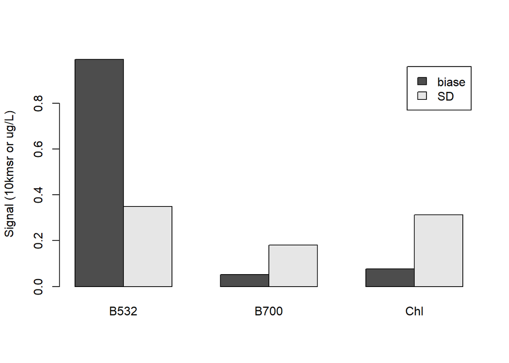

```r
  par(mfrow=c(1,1))
  barplot(biase_mat[-1,], beside=T, legend=T, ylab="Signal (10kmsr or ug/L)")
```

The data looks good for B700 and Chl: The positive biase introduced by setting negative values to 0 is well below the SD. For B532, the biase is higher, suggesting that we removed more than what is expected from the SD.

```r
  # loop through files
  for (i in unique(dat$Profile)) {

    # Extract individual profiles
    eco <- dat[dat$Profile==i,]

    # 1. Running minimum 11-point (high frequency data hence higher running mean value)
    eco$B532_rmin <- running_min(eco$B532.msr0)
    eco$B700_rmin <- running_min(eco$B700.msr0)
    eco$Chl_rmin  <- running_min(eco$Chl.ugL0)

    # Calculate spikes by removing baseline signal
    eco$B532_Spike <- eco$B532.msr0-eco$B532_rmin
    eco$B700_Spike <- eco$B700.msr0-eco$B700_rmin
    eco$Chl_Spike  <- eco$Chl.ugL0-eco$Chl_rmin

    # Add values to main df
    dat$B532_Basel[dat$Profile==i] <- eco$B532_rmin
    dat$B700_Basel[dat$Profile==i] <- eco$B700_rmin
    dat$Chl_Basel[dat$Profile==i]  <- eco$Chl_rmin

    dat$B532_Spike[dat$Profile==i] <- eco$B532_Spike
    dat$B700_Spike[dat$Profile==i] <- eco$B700_Spike
    dat$Chl_Spike[dat$Profile==i]  <- eco$Chl_Spike
  }
```

I separated background noise from spikes. I hence split 1 observation into 2 parts.

I here check the histogrammes to see how this affected the distributions.

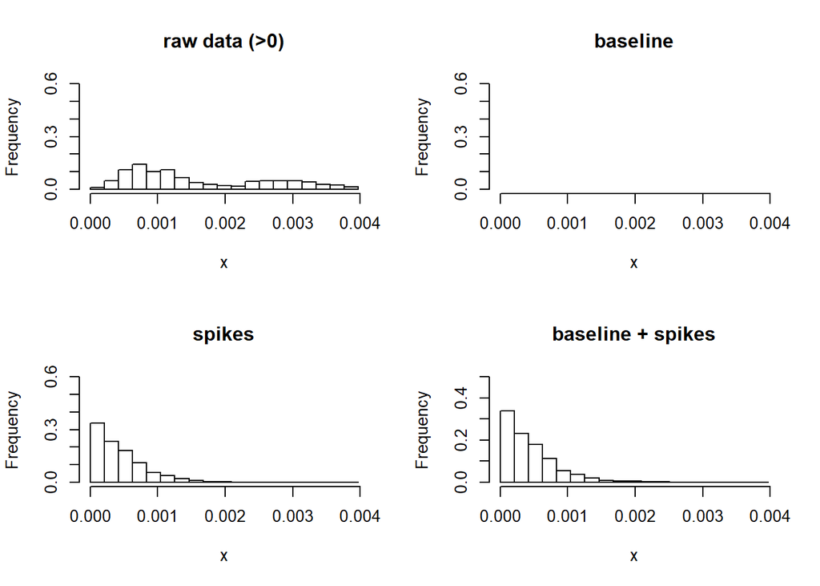

```r
  prob <- function(x, breaks=breaks, ...) {
    h <- hist(x, breaks=breaks, plot=FALSE)
    h$counts <- h$counts/sum(h$counts)
    plot(h, ...)
  }

  sub <- eco[eco$B700.msr0 <= quantile(eco$B700.msr,0.95),]

  par(mfrow=c(2,2))
  breaks <- seq(min(sub$B700.msr0), max(sub$B700.msr), length.out=20)
  prob(sub$B700.msr0 , breaks=breaks, ylim=c(0,0.6), main="raw data (>0)")
  prob(sub$B700_Basel, breaks=breaks, ylim=c(0,0.6), main="baseline")
  prob(sub$B700_Spike, breaks=breaks, ylim=c(0,0.6), main="spikes")
  prob(c(sub$B700_Basel, sub$B700_Spike), breaks=breaks, ylim=c(0,0.5), main="baseline + spikes")
```

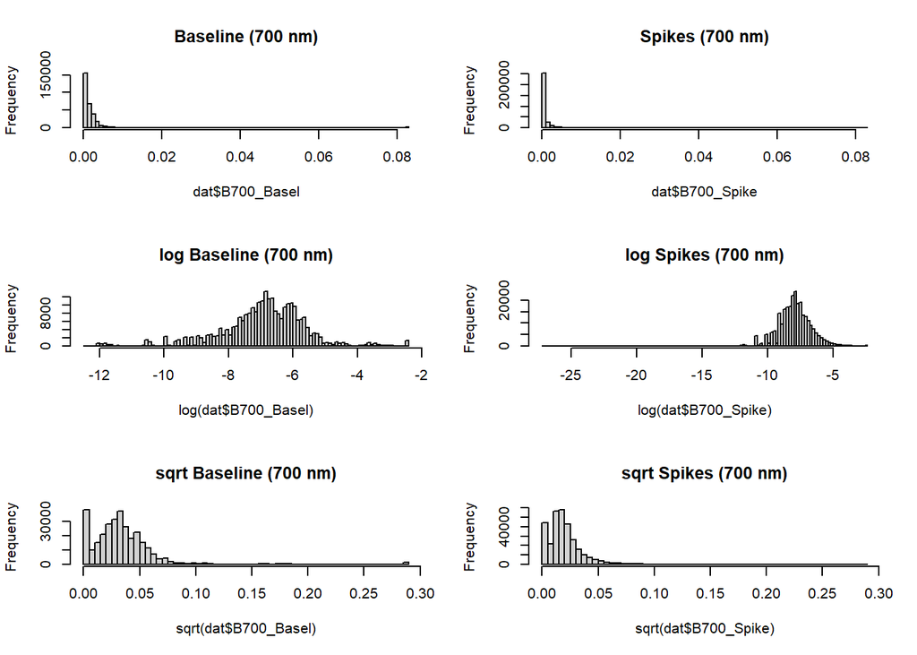

```r
  par(mfrow=c(3,2))
  hist(dat$B700_Basel, main="Baseline (700 nm)", breaks=100)
  hist(dat$B700_Spike, main="Spikes (700 nm)", breaks=100)

  hist(log(dat$B700_Basel), main="log Baseline (700 nm)", breaks=100)
  hist(log(dat$B700_Spike), main="log Spikes (700 nm)", breaks=100)

  hist(sqrt(dat$B700_Basel), main="sqrt Baseline (700 nm)", breaks=100)
  hist(sqrt(dat$B700_Spike), main="sqrt Spikes (700 nm)", breaks=100)
```

Ok, looking at the histogramme, I have to useful populations! Winning! Note that the log-transformation deletes all ‘zero’ observations, so the sqrt() transformed data is a better representation of the true distribution. The log() distribution shows that, when observed, spike height is normally distributed.

## Instrument noise

The instruments have noise which may cause artifical spike signals. I’m ignoring this here…

```r
  dat$B532_Basel_clean    <- dat$B532_Basel
  dat$B700_Basel_clean    <- dat$B700_Basel
  dat$Chl_Basel_clean     <- dat$Chl_Basel
  dat$B532_Spike_clean    <- dat$B532_Spike
  dat$B700_Spike_clean    <- dat$B700_Spike
  dat$Chl_Spike_clean     <- dat$Chl_Spike
```

## Depth bins

For spike analysis, the depth needs to be binned. I here decided on 2-m bins. Each bin starts at the nominal depth and extends for a further 2 m. For example, bin 4 ranges from 4 - 6 m depth.

```r
  bin_size      <- 2
  z_bin         <- function(x) {floor(x/bin_size)*bin_size}
  dat$Depth_bin <- z_bin(dat$Depth)
```

## Effect of downcast vs upcast

```r
  for (i in unique(dat$Profile)) {
    # Extact profile
    sub       <- dat[dat$Profile==i,]

    # Depth range
    z         <- seq(0, ceiling(max(sub$Depth)), by=1)

    # Find first occurance of maximum depth
    first_max <- which(sub$Depth==max(sub$Depth))[1]

    # Split down and upcast
    dat$UpDown[dat$Profile==i][1:(first_max-1)]     <- "dwcast"
    dat$UpDown[dat$Profile==i][first_max:nrow(sub)] <- "upcast"
  }
```

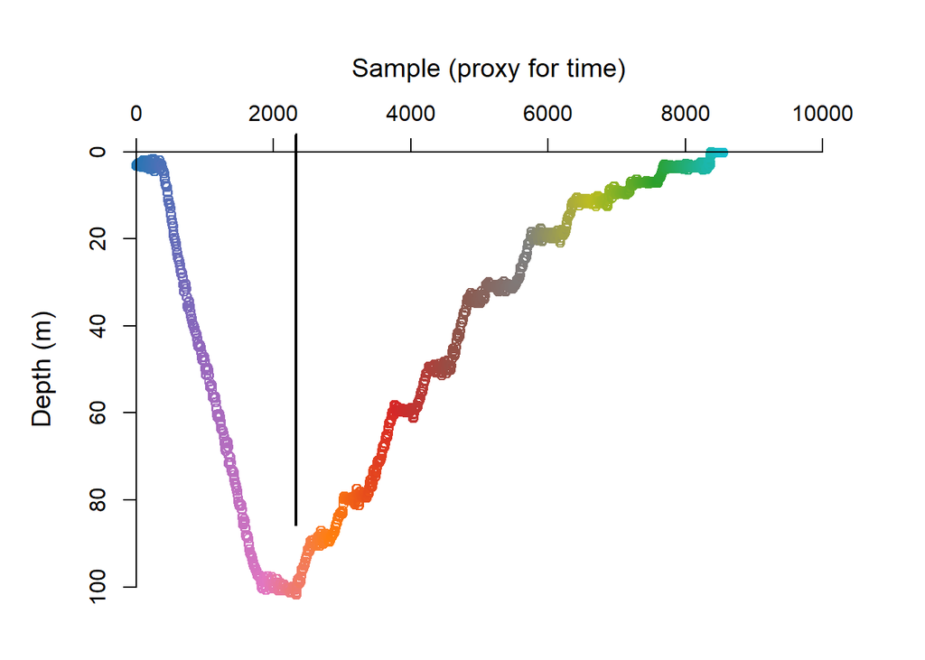

```r
  # Only use first profile for demonstration
  sub <- dat[dat$Profile==unique(dat$Profile)[4],]

  # Plot sampling depth with colour indicating time
  par(mfrow=c(1,1))
  YMAX <- 100
  zplot(1:nrow(sub),sub$Depth, ylim=c(YMAX,0), xlab="Sample (proxy for time)", col=dramp(nrow(sub)))

  # first time at maximum depth
  first_max <- which(sub$Depth==max(sub$Depth))[1]
  abline(v=first_max, col=1, lwd=2)
```

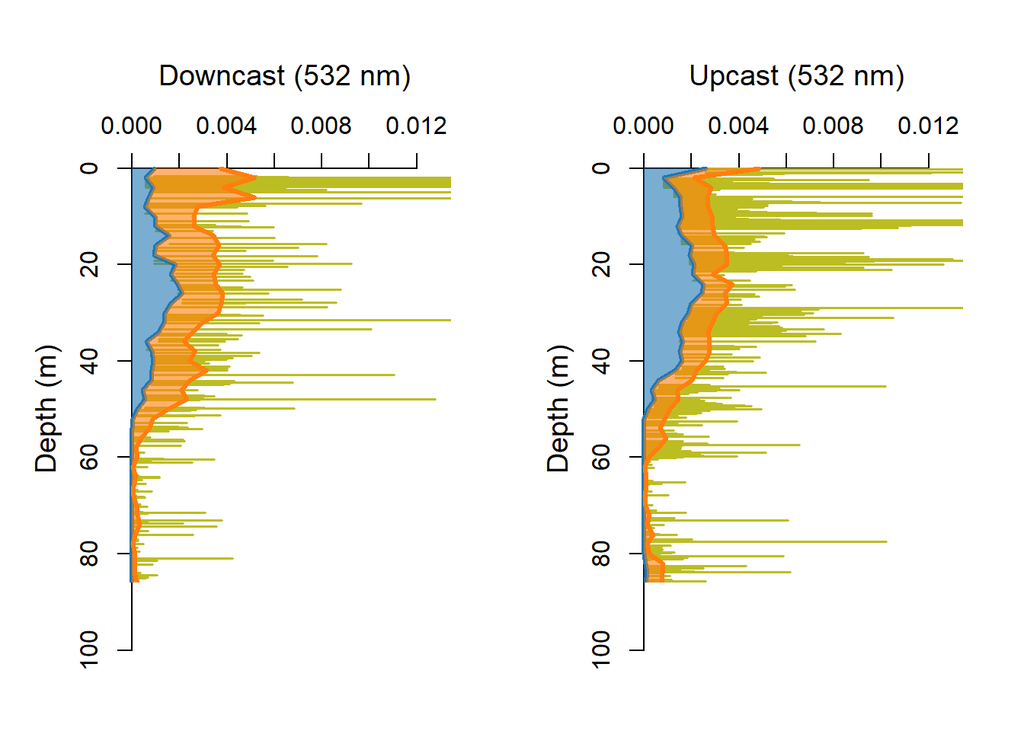

```r
  par(mfrow=c(1,2))

  # Split down and upcast
  dwcast <- sub[dat$UpDown == "dwcast", ]
  upcast <- sub[dat$UpDown == "upcast", ]

  XMAX <- quantile(c(sub$B532_Basel_clean + sub$B532_Spike_clean), 0.995)
  YMAX <- 100

  # ----- DOWNCAST -----
  # bin and plot downcast
  bin       <- aggregate(dwcast$B532_Basel_clean, by=list(dwcast$Depth_bin), mean, na.rm=T); colnames(bin) <- c("Depth","Basel")
  bin$Spike <- aggregate(dwcast$B532_Spike_clean, by=list(dwcast$Depth_bin), mean, na.rm=T)$x

  zplot(NA, NA, ylim=c(YMAX,0), xlim=c(0, XMAX), type='n', xlab="Downcast (532 nm)")

    for (i in 1:nrow(dwcast)) {
      # nearest baseline value
      dz <- dwcast$Depth_bin[i]
      if(is.na(dz)) next
      bl <- bin$Basel[bin$Depth==dz]

      # add spikes
      lines(x=c(bl,bl+dwcast$B532_Spike_clean[i]), y=c(dwcast$Depth[i],dwcast$Depth[i]), col=d3[9], lwd=1.5)
    }

    # add baseline
    polygon(x=c(bin$Basel,0,0),y=c(bin$Depth,max(bin$Depth),min(bin$Depth)), col= add_alpha(d3[1], 0.6), border=NA)
    lines(bin$Basel, bin$Depth, col=d3[1], lwd=3)

    # add bin average large particles
    polygon(x=c(bin$Basel,rev(bin$Basel+bin$Spike)),y=c(bin$Depth,rev(bin$Depth)), col= add_alpha(d3[2], 0.6), border=NA)
    lines(bin$Basel+bin$Spike, bin$Depth, col=d3[2], lwd=3)

  # ----- UPCAST -----
  # bin and plot downcast
  bin       <- aggregate(upcast$B532_Basel_clean, by=list(upcast$Depth_bin), mean, na.rm=T); colnames(bin) <- c("Depth","Basel")
  bin$Spike <- aggregate(upcast$B532_Spike_clean, by=list(upcast$Depth_bin), mean, na.rm=T)$x

  zplot(NA, NA, ylim=c(YMAX,0), xlim=c(0, XMAX), type='n', xlab="Upcast (532 nm)")

    for (i in 1:nrow(upcast)) {
      # nearest baseline value
      dz <- upcast$Depth_bin[i]
      if(is.na(dz)) next
      bl <- bin$Basel[bin$Depth==dz]

      # add spikes
      lines(x=c(bl,bl+upcast$B532_Spike_clean[i]), y=c(upcast$Depth[i],upcast$Depth[i]), col=d3[9], lwd=1.5)
    }

    # add baseline
    polygon(x=c(bin$Basel,0,0),y=c(bin$Depth,max(bin$Depth),min(bin$Depth)), col= add_alpha(d3[1], 0.6), border=NA)
    lines(bin$Basel, bin$Depth, col=d3[1], lwd=3)

    # add bin average large particles
    polygon(x=c(bin$Basel,rev(bin$Basel+bin$Spike)),y=c(bin$Depth,rev(bin$Depth)), col= add_alpha(d3[2], 0.6), border=NA)
    lines(bin$Basel+bin$Spike, bin$Depth, col=d3[2], lwd=3)
```

From the plots it becomes very clear that more spikes are recorded when lingering at a depth, such as near 2 m during the downcast, and during bottle firing on the upcast.

### Profiling speed affects spike height.

Nathan also explained that the descend/ascend speed affects spike height. The approximate bbp sample volume is just under 1 ml. This means that a particle path through the sample volume is on the order of 1 cm or less. So when profiling at 1m/s, each particle spends <0.01 s in the sample volume. At highest resolution, each bbp (or chl) measurement reported represents an average over ~ 1/16 s. This means that a spike-causing particle will only be in the sample volume for <1/6 of the sample integration time at that speed. So a single spike measurement will be an average of samples with and without the particle, meaning that the height of the spike will be 1/6 as high when the bbp sensor is moving at 1 m/s as it would be when it is still. This means that the threshold between spike and non-spike can potentially change with platform speed. This may contribute to differences you see when waiting for bottles on the upcast. This also means that the downcast (if profiling speed is consistent) is probably best for your cluster analysis.

I will check profiling speed here. I noticed that readings always come in sets of 8. So I need to set the cummulative interval to >8.

```r
  dat$Datetime      <- strptime(paste(dat$Date, dat$Time, sep=" "), format="%m/%d/%y %H:%M:%S", tz="GMT")
  dat$DTnum         <- as.numeric(dat$Datetime)

  running_sum <- function(arr, n=11){
    res = arr
    for (i in n:length(arr)) {
      res[i] = sum(arr[(i-n):i])
    }
    res
  }

  # Criteria for speed cut offs
  LEN     <- 16
  SPD_min <- 0.2
  SPD_max <- 1

  for (i in unique(dat$Profile)) {
    dat$tdiff[dat$Profile==i] <- c(NA, running_sum(diff(dat$DTnum[dat$Profile==i]), n=LEN))
    dat$speed[dat$Profile==i] <- c(NA, running_sum(diff(dat$Depth[dat$Profile==i]), n=LEN)/running_sum(diff(dat$DTnum[dat$Profile==i]), n=LEN))
  }

  # Only use first profile for demonstration
  sub <- dat[dat$Profile==unique(dat$Profile)[4],]

  # Typical time over which speed was intergrated
  par(mfrow=c(1,2))
  hist(sub$tdiff, main="Integration time (s)"); summary(sub$tdiff)
```

```
##    Min. 1st Qu.  Median    Mean 3rd Qu.    Max.    NA's
##   0.000   2.000   2.000   2.257   2.000  32.000       1
```

```r
  hist(sub$speed, main="Speed (m/s)"); summary(sub$speed)
```

```
##      Min.   1st Qu.    Median      Mean   3rd Qu.      Max.      NA's
## -1.598000 -0.343500 -0.002500  0.001107  0.331500  2.006000        13
```

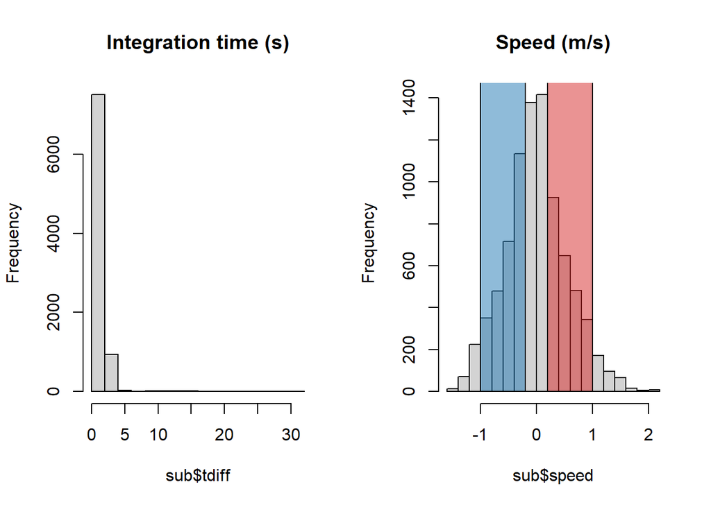

```r
  polygon(x=c(SPD_max*-1, SPD_max*-1, SPD_min*-1, SPD_min*-1), y=c(0,2000,2000,0), col=add_alpha(d3["blue"],0.5))
  polygon(x=c(SPD_max,    SPD_max,    SPD_min   , SPD_min   ), y=c(0,2000,2000,0), col=add_alpha(d3["red"], 0.5))
```

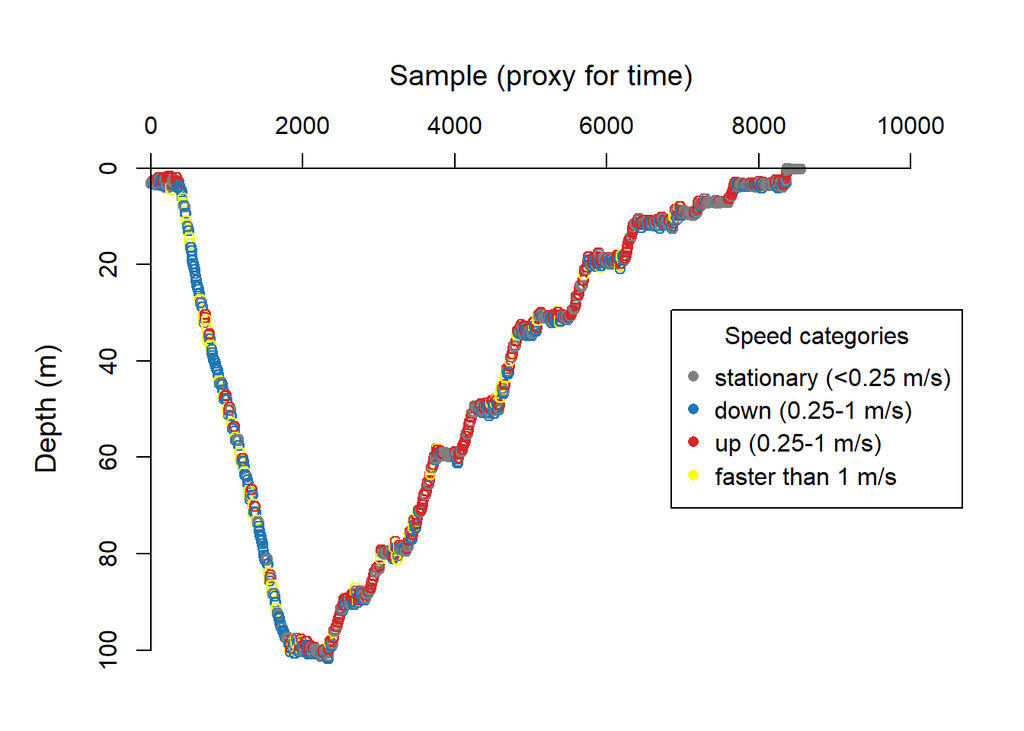

```r
  # Plot sampling depth with colour indicating time
  COL                               <- rep(d3["grey"],nrow(sub))
  COL[sub$speed      > SPD_min]     <- d3["blue"]
  COL[sub$speed      < SPD_min*-1]  <- d3["red"]
  COL[abs(sub$speed) > SPD_max]     <- "yellow"

  par(mfrow=c(1,1))
  YMAX <- 100
  zplot(1:nrow(sub),sub$Depth, ylim=c(YMAX,0), xlab="Sample (proxy for time)", col=COL)

  # legend
  legend("right", col=c(d3["grey"],d3["blue"], d3["red"], "yellow"), pch=16, title="Speed categories",
    legend=c("stationary (<0.25 m/s)", "down (0.25-1 m/s)","up (0.25-1 m/s)","faster than 1 m/s"))
```

```r
  # percentage of data meeting the speed criteria
  table(abs(dat$speed) > SPD_min & abs(dat$speed) < SPD_max & dat$Depth)/nrow(dat)
```

```
##
##     FALSE      TRUE
## 0.4628899 0.5348269
```

I will also exclude shallow samples: The spikes near the surface are likely to include bubbles. On the downcast, this includes bubbles from the sensor entering the water. On the upcast this includes natural bubbles from waves and also perhaps from the ship. So I guess I would advise not to include the top 2-5 m.

I here opted for 4 m because of the bin-sizes (i.e. bin 4 extends from 4-6 m.)

```r
  # keep data that is deeper than 4
  DEPTH_min <- 4

  # keep data within speed limits
  dat$Keep <- FALSE
  dat$Keep[abs(dat$speed) > SPD_min & abs(dat$speed) < SPD_max & dat$Depth > DEPTH_min] <- TRUE

  # data kept
  table(dat$Keep)[2]/(table(dat$Keep)[2]+table(dat$Keep)[1])
```

```
##      TRUE
## 0.4863019
```

```r
  dat_spd   <- dat[dat$Keep == TRUE,]
```

## Spike height down vs upcast

I want to check whether the spike height is the same between the down and upcast.

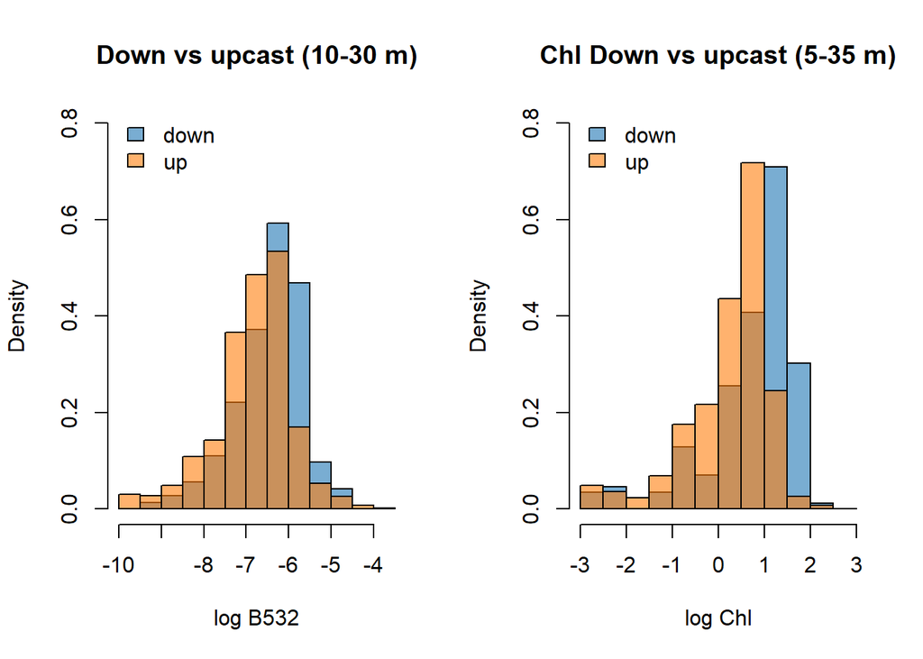

```r
  # Split Profile 4 into down and upcast
  dwcast <- dat_spd[dat_spd$UpDown == "dwcast" & dat_spd$Profile==unique(dat_spd$Profile)[4], ]
  upcast <- dat_spd[dat_spd$UpDown == "upcast" & dat_spd$Profile==unique(dat_spd$Profile)[4], ]

  # prepare plot
  par(mfrow=c(1,2))

  # ----- 532 nm -----
  # Define plotting range (in 0.5 increments)
  RNG <- c(-10, -3.5)

  # plot downcast
  hist(log(dwcast$B532_Spike_clean[dwcast$Depth>10 & dwcast$Depth <30 & dwcast$B532_Spike_clean>0]), main="Down vs upcast (10-30 m)", xlab="log B532",
    xlim=RNG, ylim=c(0, 0.8), col=add_alpha(d3[1], 0.6),
    breaks=seq(RNG[1], RNG[2], by=0.5), freq=FALSE)

  # add upcast
  hist(log(upcast$B532_Spike_clean[upcast$Depth>10 & upcast$Depth <30 & upcast$B532_Spike_clean>0]), add=T, col=add_alpha(d3[2], 0.6),
    breaks=seq(RNG[1], RNG[2], by=0.5), freq=FALSE)

  # add legend
  legend("topleft", fill=add_alpha(d3[1:2], 0.6), legend=c("down","up"), bty='n')

  # ----- Chl -----
  # Define plotting range (in 0.5 increments)
  RNG <- c(-3, 3)

  # plot downcast
  hist(log(dwcast$Chl_Spike_clean[dwcast$Depth>5 & dwcast$Depth <35 & dwcast$Chl_Spike_clean>0]), main="Chl Down vs upcast (5-35 m)", xlab="log Chl",
    xlim=RNG, ylim=c(0,0.8), col=add_alpha(d3[1], 0.6),
    breaks=seq(RNG[1], RNG[2], by=0.5), freq=FALSE)

  # add upcast
  hist(log(upcast$Chl_Spike_clean[upcast$Depth>10 & upcast$Depth <35 & upcast$Chl_Spike_clean>0]), add=T, col=add_alpha(d3[2], 0.6),
    breaks=seq(RNG[1], RNG[2], by=0.5), freq=FALSE)

  # add legend
  legend("topleft", fill=add_alpha(d3[1:2], 0.6), legend=c("down","up"), bty='n')
```

```r
  # revert plot
  par(mfrow=c(1,1))
```

When comparing the probability distribution, there seemed to have been more larger particles during the downcast. This could potentially indicate particle fragmentation during the upcast.

## Binned profiles for all stations

```r
  colnames      <- c("Depth","B532_B","B532_S","B700_B","B700_S","Chl_B","Chl_S","Profile","UpDown")
  mat           <- matrix(data=NA, nrow=0, ncol=length(colnames))
  colnames(mat) <- colnames

  # loop through files
  for (i in unique(dat_spd$Profile)) {
    # Extact profile
    sub       <- dat_spd[dat_spd$Profile==i,]

    # Split down and upcast
    dwcast    <- sub[sub$UpDown=="dwcast",]
    upcast    <- sub[sub$UpDown=="upcast",]

    # Downcast / Upcast
    for (k in c("dwcast","upcast")){

      cast    <- get(k)

      if (nrow(cast)<1) {
        print(paste("Missing data:", i, k))
        next
      }

      bin         <- aggregate(cast[,"B532_Basel_clean"], by=list(cast$Depth_bin), mean, na.rm=T); colnames(bin) <- c("Depth","B532_B")
      bin$B532_S  <- aggregate(cast[,"B532_Spike_clean"], by=list(cast$Depth_bin), mean, na.rm=T)$x

      bin$B700_B  <- aggregate(cast[,"B700_Basel_clean"], by=list(cast$Depth_bin), mean, na.rm=T)$x
      bin$B700_S  <- aggregate(cast[,"B700_Spike_clean"], by=list(cast$Depth_bin), mean, na.rm=T)$x

      bin$Chl_B   <- aggregate(cast[,"Chl_Basel_clean"], by=list(cast$Depth_bin), mean, na.rm=T)$x
      bin$Chl_S   <- aggregate(cast[,"Chl_Spike_clean"], by=list(cast$Depth_bin), mean, na.rm=T)$x

      bin$Profile <- i
      bin$UpDown  <- k

      mat         <- rbind(mat, bin)
    }
  }
```

```
## [1] "Missing data: EcoPuck_045 dwcast"
```

```r
  bb <- mat

  # Add metadata
  bb$Bottom_depth <- meta$Bottom_depth[match(bb$Profile, meta$Profile)]
  bb$SML          <- meta$SML         [match(bb$Profile, meta$Profile)]
  bb$BML01        <- meta$BML01       [match(bb$Profile, meta$Profile)]
  bb$BML02        <- meta$BML02       [match(bb$Profile, meta$Profile)]

  # Zones
  bb$Zone                     <- "Mid"
  bb$Zone[bb$Depth<bb$SML]    <- "SML"
  bb$Zone[bb$Depth>bb$BML02]  <- "BML"

  # Region
  bb$Date                 <- meta$Date[match(bb$Profile, meta$Profile)]
  bb$Lon                  <- meta$Lon [match(bb$Profile, meta$Profile)]
  bb$Lat                  <- meta$Lat [match(bb$Profile, meta$Profile)]
  bb$Region[bb$Lon > 26]  <- "E"
  bb$Region[bb$Lon < 26]  <- "W"
```

I now have a master data frame that contains the decomposed (large and small particles) for 2-m bins for all profiles.

```r
  knitr::opts_knit$set(root.dir = "C:/Users/slcg/Dropbox/SOLSTICE/EK188/EcoPuck/DATA/")
  setwd("C:/Users/slcg/Dropbox/SOLSTICE/EK188/EcoPuck/DATA/")

  write.csv(bb, "2020-04-27 2m-binned ecotriplet particle concentrations.csv", row.names=F)
```

## Vertical distribution plots

Show particle concentrations vertically resolved from West to East.

```r
  # sort profiles according to longitude
  sort <- data.frame(Profile = meta$Profile[order(meta$Lon)], Order = 1:length(meta$Profile))

  # add Grid to sort
  sort$Grid           <- meta$Grid        [match(sort$Profile, meta$Profile)]
  sort$SML            <- meta$SML         [match(sort$Profile, meta$Profile)]
  sort$BML01          <- meta$BML01       [match(sort$Profile, meta$Profile)]
  sort$BML02          <- meta$BML02       [match(sort$Profile, meta$Profile)]
  sort$Bottom_depth   <- meta$Bottom_depth[match(sort$Profile, meta$Profile)]

  # add order to data
  bb$Order <- sort$Order[match(bb$Profile, sort$Profile)]

  # add 0.5 increment for Upcast
  bb$Order[bb$UpDown %in% "upcast"] <- bb$Order[bb$UpDown %in% "upcast"] + 0.5
```

```r
  # ----- Shape parameters -----
  # positions on x-axis
  x <- seq(1, 47.5, by=0.5)

  # spline for depths
  spline_SML          <- as.data.frame(spline(x, rep(c(sort$SML*  -1), each=2)))
  spline_BML01        <- as.data.frame(spline(x, rep(c(sort$BML01*-1), each=2)))
  spline_BML02        <- as.data.frame(spline(x, rep(c(sort$BML02*-1), each=2)))
  spline_Bottom_depth <- as.data.frame(spline(x, rep(c(sort$Bottom_depth*-1), each=2)))

  spline_Bottom_depth$y[spline_Bottom_depth$y < -199] <- -199

  # add points to make polygon round
  spline_Bottom_depth <- rbind(c(1, -400), spline_Bottom_depth, c(47.5, -199), c(1, -199))
```

Some depth bins have not values (e.g. removed during quality control, e.g. because of wrong sampling speed). I will interpolate these bins using quasi-linear regressions.

```r
  bb_int <- bb

  df      <- bb_int[0,]
  counter <- 1

  # ---- Interpolate ----
  # Interpolate missing depth bins
  for (i in bb_int$Order){
    x <- bb_int[bb_int$Order %in% i ,]

    # find max depth
    z_max <- max(bb_int[bb_int$Order %in% i ,]$Depth)

    # define bins that should be there
    SEQ <- seq(4, z_max, by=2)

    # find missing bins
    missing <- SEQ[(SEQ %in% bb_int[bb_int$Order %in% i ,]$Depth)==FALSE]
    there   <- SEQ[(SEQ %in% bb_int[bb_int$Order %in% i ,]$Depth)==TRUE]

    # make new row
    for (k in missing){

      shallow <- max(there[there<k])
      deep    <- min(there[there>k])

      # if no data to interpolate, next
      if (any(is.infinite(shallow), is.infinite(deep))) next

      # find row number of bin above
      ROW     <- which(bb_int$Order %in% i & bb_int$Depth %in% shallow)

      # make new row by copying the bin above
      new_row <- bb_int[ROW,]
      rownames(new_row) <- paste("int", counter, sep="")

      # replace depth
      new_row$Depth <- k

      # interpolate values
      new_row[,c("B532_B", "B532_S", "B700_B", "B700_S", "Chl_B", "Chl_S")] <-
        colMeans(bb_int[bb_int$Order %in% i & bb_int$Depth %in% c(shallow, deep),
                 c("B532_B", "B532_S", "B700_B", "B700_S", "Chl_B", "Chl_S")])

      # add to df
      bb_int <- rbind(bb_int, new_row)

      # increase counter
      counter <- counter + 1
    }
  }

  # Make negative depth for plotting
  bb_int$Depth_neg <- bb_int$Depth * -1
```

I now loop through the different variables and plot the depth profiles.

Note, as I am using ggplot within a loop, I need to use the function “aes_string” rather than “aes”. Each plot is then saved to a list and returned using ggarrange.

```
## [1] 1
## [1] "B532_B"
## [1] 2
## [1] "B532_S"
```

[output not shown]

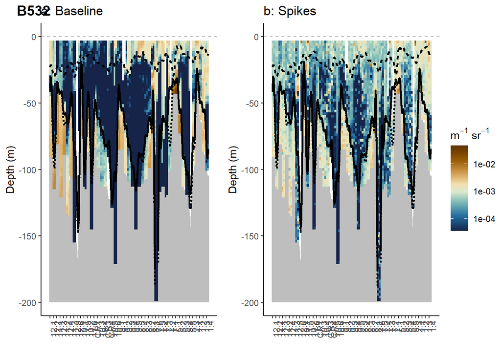

[output not shown]

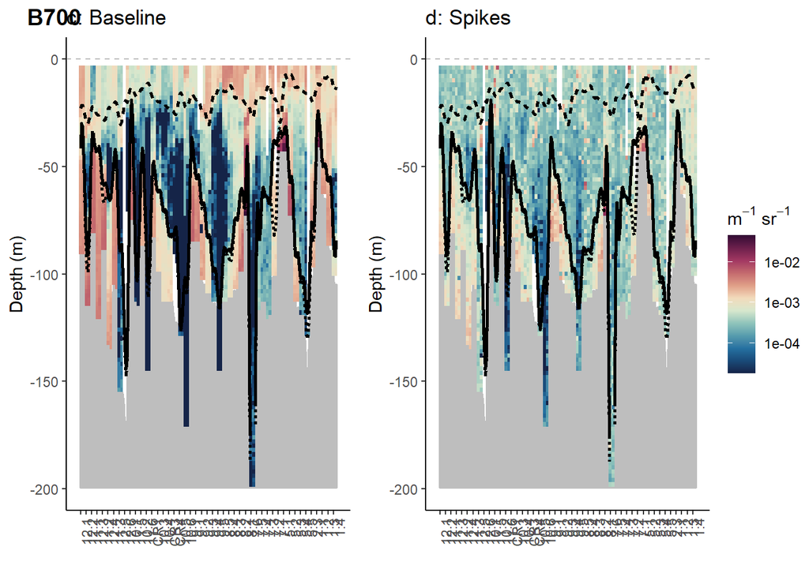

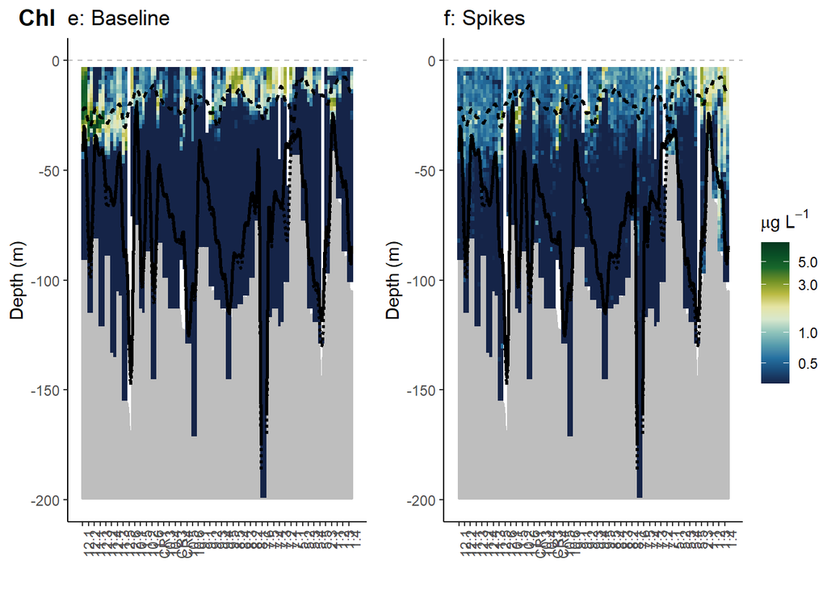

```r
  # required
  library(ggplot2)
  library(ggpubr)

  part_grn <- colorRampPalette(c(
    "#152448ff",
    "#1d6aa0ff",
    "#77b9b5ff",
    "#fbf9d6ff",
    "#abac21ff",
    "#0b632cff",
    "#083920ff"))

  part_bwn <- colorRampPalette(c(
    "#152448ff",
    "#1d6aa0ff",
    "#77b9b5ff",
    "#fbf9d6ff",
    "#d9a355ff",
    "#975a00ff",
    "#5f3200ff"
    ))

  part_red <- colorRampPalette(c(
    "#152448ff",
    "#1d6aa0ff",
    "#77b9b5ff",
    "#fbf9d6ff",
    "#DB8C77ff",
    "#9D3060ff",
    "#340D35ff"
    ))

  # ----- Loop -----
  COUNTER <- 1

  for (i in c("B532", "B700", "Chl")){

    #if (grepl("532", i)) {SCALE <- cmocean::cmocean("amp")(12)  ; RNG <- c(biase_mat["SD","B532"]/SC, max(bb$B532_B))}
    #if (grepl("700", i)) {SCALE <- cmocean("algae")(50)         ; RNG <- c(biase_mat["SD","B700"]/SC, max(bb$B700_B))}
    #if (grepl("Chl", i)) {SCALE <- rev(cmocean("ice")(50))      ; RNG <- c(biase_mat["SD","Chl" ]    , max(bb$Chl_B ))}

    if (grepl("532", i)) {SCALE <- part_bwn(12); RNG <- c(biase_mat["SD","B532"]/SC, max(bb$B532_B)); NAV <- part_red(12)[1]; UNIT <- expression(paste(m^-1, " ", s, r^-1))}
    if (grepl("700", i)) {SCALE <- part_red(12); RNG <- c(biase_mat["SD","B700"]/SC, max(bb$B700_B)); NAV <- part_bwn(12)[1]; UNIT <- expression(paste(m^-1, " ", s, r^-1))}
    if (grepl("Chl", i)) {SCALE <- part_grn(12); RNG <- c(biase_mat["SD","Chl"], max(bb$Chl_B));      NAV <- part_grn(12)[1]; UNIT <- expression(paste(mu, g, " ", L^-1))}

    # --- double plots ---
    # make list to save plots
    plot_list     <- list()

    # set counter
    INNER_COUNTER <- 1

    for (k in c("B", "S")) {
      VAR <- paste(i, k, sep="_")

      if(k == "B") TYPE <- "Baseline"
      if(k == "S") TYPE <- "Spikes"

      # plot glider estimates
      g_loop <- ggplot() +
        # title
        labs(title = paste(letters[COUNTER], ": ", TYPE, sep=""), x = "", y = "Depth (m)", fill = UNIT) +

        # add surface line
        geom_hline(yintercept = 0, linetype = "dashed", color = "grey") +

        # add seabed
        geom_polygon(data = spline_Bottom_depth, aes(x = x, y = y), colour = "grey", fill = "grey", size=1) +

        # add tiles
        geom_tile(data = bb_int, aes_string(x = "Order", y = "Depth_neg", fill = VAR), show.legend=T) +

        # define colour
        scale_fill_gradientn(colours = SCALE, limits = RNG, na.value = NAV, trans="log10") +

        # define plot area
        ylim(-200, 0) +

        # remove grey background
        theme(panel.grid.major = element_blank(), panel.grid.minor = element_blank(), panel.background = element_blank(), axis.line = element_line(colour = "black"), axis.text.x = element_text(angle = 90, hjust = 1)) +

        # change axis label
        scale_x_continuous(breaks = sort$Order, labels = sort$Grid) +

        # add SML
        geom_line(data = spline_SML, aes(x = x, y = y), colour = 1, size = 1, linetype = "22") +

        # add BML
        # note: line type is a custom design: 1 unit "on"; 1 unit "off"
        geom_line(data = spline_BML01, aes(x = x, y = y), colour = 1, size = 1, linetype = "11") +
        geom_line(data = spline_BML02, aes(x = x, y = y), colour = 1, size = 1)

        # save plot in list
        plot_list[[INNER_COUNTER]] <- g_loop
        print(INNER_COUNTER)
        print(VAR)

        COUNTER       <- COUNTER + 1
        INNER_COUNTER <- INNER_COUNTER + 1
    }

    # --- save for pulication ---
    ggsave(
      # choose plots
      ggarrange(plot_list[[1]], plot_list[[2]],

        # plot design
        ncol=2, nrow=1, common.legend = TRUE, legend="right"),

      # file name and type
      file = paste0("plots/plot_", i, ".png"), device = "png",

      # plot dimensions
      width =  90*2*2, height = 69*2, units = "mm")

    # --- print in markdown ---
    # add title and print
    print(
      ggarrange(

        # choose plots
        plot_list[[1]], plot_list[[2]],

        # plot design
        ncol = 2, nrow = 1, common.legend = TRUE, legend = "right",

        # add title
        labels=list(title=i)
      )
    )
  }
```

### Backscatter ratios

```r
  BWY <- colorRampPalette(c(
    d3[3],
    "goldenrod2",
    d3[4]
    ))

  BWY <- colorRampPalette(c(
    d3[1],
    "lightgrey",
    "goldenrod2"
    ))

  # green:red
  bb_int$dynm_ratio <- bb_int$B532_B/bb_int$B700_B
  bb_int$dynm_ratio[is.infinite(bb_int$dynm_ratio)] <- 10
  bb_int$dynm_ratio[bb_int$B532_B < (3.487e-05*2) & bb_int$B700_B < (1.8024e-05*2)] <- NA

  summary(bb_int$dynm_ratio)
```

```
##    Min. 1st Qu.  Median    Mean 3rd Qu.    Max.    NA's
##  0.0000  0.0000  0.3121  0.4704  0.8362 10.0000    1054
```

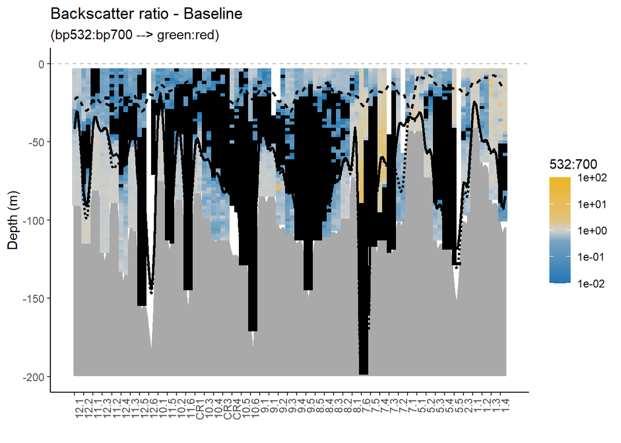

```r
  # plot glider estimates
  g_dynm_ratio <- ggplot() +
    # title
    labs(title = "Backscatter ratio - Baseline", subtitle = "(bp532:bp700 --> green:red)", x = "", y = "Depth (m)", fill = "532:700") +

    # add surface line
    geom_hline(yintercept = 0, linetype = "dashed", color = "grey") +

    # add Bethos
    geom_polygon(data = spline_Bottom_depth, aes(x = x, y = y), colour = "darkgrey", fill = "darkgrey", size=1) +

    # add tiles
    geom_tile(data = bb_int, aes(x = Order, y = c(Depth*-1), fill = dynm_ratio)) +

    # define colour
    scale_fill_gradientn(colours = BWY(12),
                         na.value = "black",
                         trans="log10",
                         limits = c(0.01,100),
                         values=scales::rescale(c(-1,-0.2,0,0.2,1)), # sets distribution on scale (after trans)
    ) +

    #scale_fill_gradientn(colours = cmocean::cmocean("balance")(12), na.value = cmocean::cmocean("balance")(12)[1],
    #  limits = c(0.01,10),
    #  values=scales::rescale(c(1,3,4)), # sets distribution on scale (after trans)
    #  trans="log10") +

    # define plot area
    ylim(-200, 0) +

    # remove grey background
    theme(panel.grid.major = element_blank(), panel.grid.minor = element_blank(), panel.background = element_blank(), axis.line = element_line(colour = "black"), axis.text.x = element_text(angle = 90, hjust = 1)) +

    # change axis label
    scale_x_continuous(breaks = sort$Order, labels = sort$Grid) +

    # add SML
    geom_line(data = spline_SML, aes(x = x, y = y), colour = 1, size = 1, linetype = "22") +

    # add BML
    # note: line type is a custom design: 1 unit "on"; 1 unit "off"
    geom_line(data = spline_BML01, aes(x = x, y = y), colour = 1, size = 1, linetype = "11") +
    geom_line(data = spline_BML02, aes(x = x, y = y), colour = 1, size = 1)

  g_dynm_ratio
```

```r
  # green:red
  bb_int$dynm_ratio <- bb_int$B532_S/bb_int$B700_S
  bb_int$dynm_ratio[is.infinite(bb_int$dynm_ratio)] <- 34
  bb_int$dynm_ratio[bb_int$B532_S < (3.487e-05*2) & bb_int$B700_S < (1.8024e-05*2)] <- NA

  summary(bb_int$dynm_ratio)
```

```
##    Min. 1st Qu.  Median    Mean 3rd Qu.    Max.    NA's
##  0.0000  0.3479  1.0314  1.1658  1.5580 34.0000     151
```

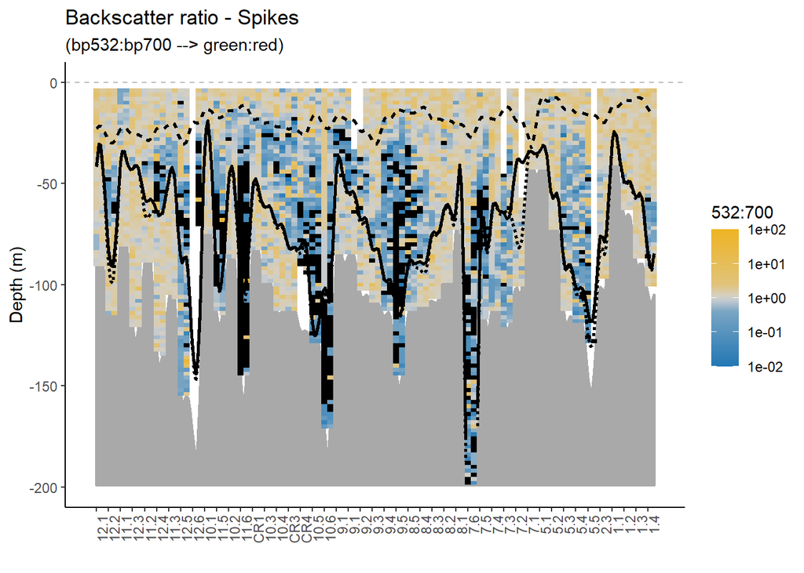

```r
  # plot glider estimates
  g_dynm_ratio <- ggplot() +
    # title
    labs(title = "Backscatter ratio - Spikes", subtitle = "(bp532:bp700 --> green:red)", x = "", y = "Depth (m)", fill = "532:700") +

    # add surface line
    geom_hline(yintercept = 0, linetype = "dashed", color = "grey") +

    # add Bethos
    geom_polygon(data = spline_Bottom_depth, aes(x = x, y = y), colour = "darkgrey", fill = "darkgrey", size=1) +

    # add tiles
    geom_tile(data = bb_int, aes(x = Order, y = c(Depth*-1), fill = dynm_ratio)) +

    # define colour
    scale_fill_gradientn(colours = BWY(12),
                         na.value = "black",
                         trans="log10",
                         limits = c(0.01,100),
                         values=scales::rescale(c(-1,-0.2,0,0.2,1)), # sets distribution on scale (after trans)
    ) +

    #scale_fill_gradientn(colours = cmocean::cmocean("balance")(12), na.value = cmocean::cmocean("balance")(12)[1],
    #  limits = c(0.01,10),
    #  values=scales::rescale(c(1,3,4)), # sets distribution on scale (after trans)
    #  trans="log10") +

    # define plot area
    ylim(-200, 0) +

    # remove grey background
    theme(panel.grid.major = element_blank(), panel.grid.minor = element_blank(), panel.background = element_blank(), axis.line = element_line(colour = "black"), axis.text.x = element_text(angle = 90, hjust = 1)) +

    # change axis label
    scale_x_continuous(breaks = sort$Order, labels = sort$Grid) +

    # add SML
    geom_line(data = spline_SML, aes(x = x, y = y), colour = 1, size = 1, linetype = "22") +

    # add BML
    # note: line type is a custom design: 1 unit "on"; 1 unit "off"
    geom_line(data = spline_BML01, aes(x = x, y = y), colour = 1, size = 1, linetype = "11") +
    geom_line(data = spline_BML02, aes(x = x, y = y), colour = 1, size = 1)

  g_dynm_ratio
```

```r
  # green:red
  bb_int$dynm_ratio <- (bb_int$B532_B+bb_int$B532_S)/(bb_int$B700_B+bb_int$B700_S)
  bb_int$dynm_ratio[is.infinite(bb_int$dynm_ratio)] <- 30
  bb_int$dynm_ratio[bb_int$B532_B < (3.487e-05*2) & bb_int$B700_B < (1.8024e-05*2)] <- NA

  summary(bb_int$dynm_ratio)
```

```
##    Min. 1st Qu.  Median    Mean 3rd Qu.    Max.    NA's
##  0.0000  0.3993  0.7438  0.7679  1.0238 11.1256    1054
```

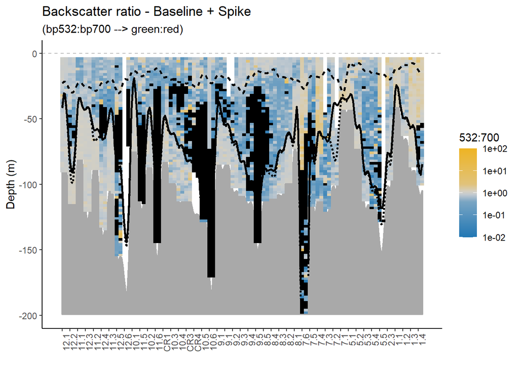

```r
  # plot glider estimates
  g_dynm_ratio <- ggplot() +
    # title
    labs(title = "Backscatter ratio - Baseline + Spike", subtitle = "(bp532:bp700 --> green:red)", x = "", y = "Depth (m)", fill = "532:700") +

    # add surface line
    geom_hline(yintercept = 0, linetype = "dashed", color = "grey") +

    # add Bethos
    geom_polygon(data = spline_Bottom_depth, aes(x = x, y = y), colour = "darkgrey", fill = "darkgrey", size=1) +

    # add tiles
    geom_tile(data = bb_int, aes(x = Order, y = c(Depth*-1), fill = dynm_ratio)) +

    # define colour
    scale_fill_gradientn(colours = BWY(12),
                         na.value = "black",
                         trans="log10",
                         limits = c(0.01,100),
                         values=scales::rescale(c(-1,-0.2,0,0.2,1)), # sets distribution on scale (after trans)
    ) +

    #scale_fill_gradientn(colours = cmocean::cmocean("balance")(12), na.value = cmocean::cmocean("balance")(12)[1],
    #  limits = c(0.01,10),
    #  values=scales::rescale(c(1,3,4)), # sets distribution on scale (after trans)
    #  trans="log10") +

    # define plot area
    ylim(-200, 0) +

    # remove grey background
    theme(panel.grid.major = element_blank(), panel.grid.minor = element_blank(), panel.background = element_blank(), axis.line = element_line(colour = "black"), axis.text.x = element_text(angle = 90, hjust = 1)) +

    # change axis label
    scale_x_continuous(breaks = sort$Order, labels = sort$Grid) +

    # add SML
    geom_line(data = spline_SML, aes(x = x, y = y), colour = 1, size = 1, linetype = "22") +

    # add BML
    # note: line type is a custom design: 1 unit "on"; 1 unit "off"
    geom_line(data = spline_BML01, aes(x = x, y = y), colour = 1, size = 1, linetype = "11") +
    geom_line(data = spline_BML02, aes(x = x, y = y), colour = 1, size = 1)

  g_dynm_ratio
```